Title: Redwine data analysis Thuy Quach Dec, 2015

========================================================

This document is final submission for Explore and Summarize Data project, Udacity Data Analyst Nanodegree Program https://www.udacity.com/course/data-analyst-nanodegree–nd002.

The data set using in this assignment was the redwine data. Descriptions about the data set can be found here https://s3.amazonaws.com/udacity-hosted-downloads/ud651/wineQualityInfo.txt.

The analysis included: data structure, statistical summary, distribution plots, boxplots of each variables vs. quality, correlation matrix and scatter plots, final plots and data exploring the strong correlated variables, and reflections.

### Load the packages:

```r
# Load all of the packages for ploting and statistical analysis-------------
library(ggplot2)
install.packages(c("psych","GPArotation","MASS"), repos = 'http://cran.us.r-project.org')
library(dplyr)
library(data.table)
library(reshape2)
install.packages("gridExtra", repos = 'http://cran.us.r-project.org')
library(gridExtra)
```

## 1.Analysis:

### 1.1 Load the Data:

```r
getwd()
```

```
## [1] "/Users/thuy/Documents/Data analysis R"
```

```r
setwd('~/Documents/Data analysis R/')
redwine <- read.csv(file = 'wineQualityReds.csv', sep = ",", header = TRUE)
```

### 1.2 Summary of the Data Set:

```
## [1] 1599   13
```

```
##  [1] "X"                    "fixed.acidity"        "volatile.acidity"
##  [4] "citric.acid"          "residual.sugar"       "chlorides"
##  [7] "free.sulfur.dioxide"  "total.sulfur.dioxide" "density"
## [10] "pH"                   "sulphates"            "alcohol"
## [13] "quality"
```

```
## 'data.frame':    1599 obs. of  13 variables:
##  $ X                   : int  1 2 3 4 5 6 7 8 9 10 ...
##  $ fixed.acidity       : num  7.4 7.8 7.8 11.2 7.4 7.4 7.9 7.3 7.8 7.5 ...
##  $ volatile.acidity    : num  0.7 0.88 0.76 0.28 0.7 0.66 0.6 0.65 0.58 0.5 ...
##  $ citric.acid         : num  0 0 0.04 0.56 0 0 0.06 0 0.02 0.36 ...
##  $ residual.sugar      : num  1.9 2.6 2.3 1.9 1.9 1.8 1.6 1.2 2 6.1 ...
##  $ chlorides           : num  0.076 0.098 0.092 0.075 0.076 0.075 0.069 0.065 0.073 0.071 ...
##  $ free.sulfur.dioxide : num  11 25 15 17 11 13 15 15 9 17 ...
##  $ total.sulfur.dioxide: num  34 67 54 60 34 40 59 21 18 102 ...
##  $ density             : num  0.998 0.997 0.997 0.998 0.998 ...
##  $ pH                  : num  3.51 3.2 3.26 3.16 3.51 3.51 3.3 3.39 3.36 3.35 ...
##  $ sulphates           : num  0.56 0.68 0.65 0.58 0.56 0.56 0.46 0.47 0.57 0.8 ...
##  $ alcohol             : num  9.4 9.8 9.8 9.8 9.4 9.4 9.4 10 9.5 10.5 ...
##  $ quality             : int  5 5 5 6 5 5 5 7 7 5 ...
```

```
##        X          fixed.acidity   volatile.acidity  citric.acid
##  Min.   :   1.0   Min.   : 4.60   Min.   :0.1200   Min.   :0.000
##  1st Qu.: 400.5   1st Qu.: 7.10   1st Qu.:0.3900   1st Qu.:0.090
##  Median : 800.0   Median : 7.90   Median :0.5200   Median :0.260
##  Mean   : 800.0   Mean   : 8.32   Mean   :0.5278   Mean   :0.271
##  3rd Qu.:1199.5   3rd Qu.: 9.20   3rd Qu.:0.6400   3rd Qu.:0.420
##  Max.   :1599.0   Max.   :15.90   Max.   :1.5800   Max.   :1.000
##  residual.sugar     chlorides       free.sulfur.dioxide
##  Min.   : 0.900   Min.   :0.01200   Min.   : 1.00
##  1st Qu.: 1.900   1st Qu.:0.07000   1st Qu.: 7.00
##  Median : 2.200   Median :0.07900   Median :14.00
##  Mean   : 2.539   Mean   :0.08747   Mean   :15.87
##  3rd Qu.: 2.600   3rd Qu.:0.09000   3rd Qu.:21.00
##  Max.   :15.500   Max.   :0.61100   Max.   :72.00
##  total.sulfur.dioxide    density             pH          sulphates
##  Min.   :  6.00       Min.   :0.9901   Min.   :2.740   Min.   :0.3300
##  1st Qu.: 22.00       1st Qu.:0.9956   1st Qu.:3.210   1st Qu.:0.5500
##  Median : 38.00       Median :0.9968   Median :3.310   Median :0.6200
##  Mean   : 46.47       Mean   :0.9967   Mean   :3.311   Mean   :0.6581
##  3rd Qu.: 62.00       3rd Qu.:0.9978   3rd Qu.:3.400   3rd Qu.:0.7300
##  Max.   :289.00       Max.   :1.0037   Max.   :4.010   Max.   :2.0000
##     alcohol         quality
##  Min.   : 8.40   Min.   :3.000
##  1st Qu.: 9.50   1st Qu.:5.000
##  Median :10.20   Median :6.000
##  Mean   :10.42   Mean   :5.636
##  3rd Qu.:11.10   3rd Qu.:6.000
##  Max.   :14.90   Max.   :8.000
```

### Observations from the Data:

Data structures:

Statistical observations:

- Most the wine was ranked 5, 6 or 7 for quality. There was only small proportion in 3,4 or 8 categories. There was none in 1, 2 or 10.

### Questions from the data

1. Which chemical properties influence the quality of red wines?
2. Under what conditions the quality of red wines is the best?

### 1.3 Distribution of individual variables by histogram:

First, let us explore the distributions of each variables using ggplot.

The data is in the format of wide data which make difficult for R to draw multiple variable plots. Therefore, I reshaped the data into long format.

```r
# reshape data into long format
long_data <- melt(redwine, id.vars=c("X", "quality"))
```

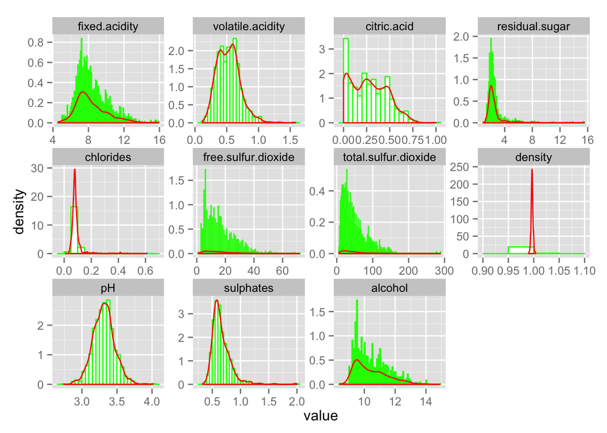

```r
# plot the distribution and density
dist_plot <- ggplot(long_data, aes(x=value)) +  geom_histogram(aes(y= ..density..), binwidth=0.05, colour="green", fill="white") + geom_density(color = "red", alpha = 0.2)

 # iterate plot
dist_plot + facet_wrap(~ variable, scales = "free")
```

Some of the variables seem to follow normal distribution such as density, pH and fix.acidity while few others are right skewed distribution such as residual.sugar, free.sulfur.dioxide, total.sulfur.dioxide, sulphate, alcohol.

### 1.4 Correlation of chemical properties vs. wine quality by boxplot:

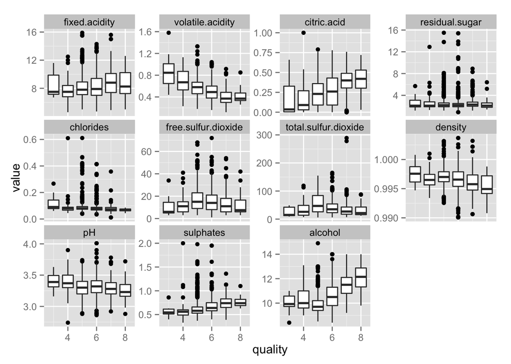

```r
# correlation boxplot and iterate by variables
box_plot <- ggplot(long_data, aes(x = quality, y = value)) +
  facet_wrap(~ variable, scales="free_y")

 # groupby quality
box_plot + geom_boxplot(aes_string(group = 'quality'))
```

### 1.5 Correlation matrix:

As the variables were physicochemical properties of wine, they could be highly correlated with each others. Let us explore their relationships.

```r
# calculate the correlation coefficients matrix
var_redwine_variables = cor(x=redwine[,2:13], y=redwine$rating)
var_redwine_variables
```

```
##                      fixed.acidity volatile.acidity citric.acid
## fixed.acidity           1.00000000     -0.256130895  0.67170343
## volatile.acidity       -0.25613089      1.000000000 -0.55249568
## citric.acid             0.67170343     -0.552495685  1.00000000
## residual.sugar          0.11477672      0.001917882  0.14357716
## chlorides               0.09370519      0.061297772  0.20382291
## free.sulfur.dioxide    -0.15379419     -0.010503827 -0.06097813
## total.sulfur.dioxide   -0.11318144      0.076470005  0.03553302
## density                 0.66804729      0.022026232  0.36494718
## pH                     -0.68297819      0.234937294 -0.54190414
## sulphates               0.18300566     -0.260986685  0.31277004
## alcohol                -0.06166827     -0.202288027  0.10990325
## quality                 0.12405165     -0.390557780  0.22637251
##                      residual.sugar    chlorides free.sulfur.dioxide
## fixed.acidity           0.114776724  0.093705186        -0.153794193
## volatile.acidity        0.001917882  0.061297772        -0.010503827
## citric.acid             0.143577162  0.203822914        -0.060978129
## residual.sugar          1.000000000  0.055609535         0.187048995
## chlorides               0.055609535  1.000000000         0.005562147
## free.sulfur.dioxide     0.187048995  0.005562147         1.000000000
## total.sulfur.dioxide    0.203027882  0.047400468         0.667666450
## density                 0.355283371  0.200632327        -0.021945831
## pH                     -0.085652422 -0.265026131         0.070377499
## sulphates               0.005527121  0.371260481         0.051657572
## alcohol                 0.042075437 -0.221140545        -0.069408354
## quality                 0.013731637 -0.128906560        -0.050656057
##                      total.sulfur.dioxide     density          pH
## fixed.acidity                 -0.11318144  0.66804729 -0.68297819
## volatile.acidity               0.07647000  0.02202623  0.23493729
## citric.acid                    0.03553302  0.36494718 -0.54190414
## residual.sugar                 0.20302788  0.35528337 -0.08565242
## chlorides                      0.04740047  0.20063233 -0.26502613
## free.sulfur.dioxide            0.66766645 -0.02194583  0.07037750
## total.sulfur.dioxide           1.00000000  0.07126948 -0.06649456
## density                        0.07126948  1.00000000 -0.34169933
## pH                            -0.06649456 -0.34169933  1.00000000
## sulphates                      0.04294684  0.14850641 -0.19664760
## alcohol                       -0.20565394 -0.49617977  0.20563251
## quality                       -0.18510029 -0.17491923 -0.05773139
##                         sulphates     alcohol     quality
## fixed.acidity         0.183005664 -0.06166827  0.12405165
## volatile.acidity     -0.260986685 -0.20228803 -0.39055778
## citric.acid           0.312770044  0.10990325  0.22637251
## residual.sugar        0.005527121  0.04207544  0.01373164
## chlorides             0.371260481 -0.22114054 -0.12890656
## free.sulfur.dioxide   0.051657572 -0.06940835 -0.05065606
## total.sulfur.dioxide  0.042946836 -0.20565394 -0.18510029
## density               0.148506412 -0.49617977 -0.17491923
## pH                   -0.196647602  0.20563251 -0.05773139
## sulphates             1.000000000  0.09359475  0.25139708
## alcohol               0.093594750  1.00000000  0.47616632
## quality               0.251397079  0.47616632  1.00000000
```

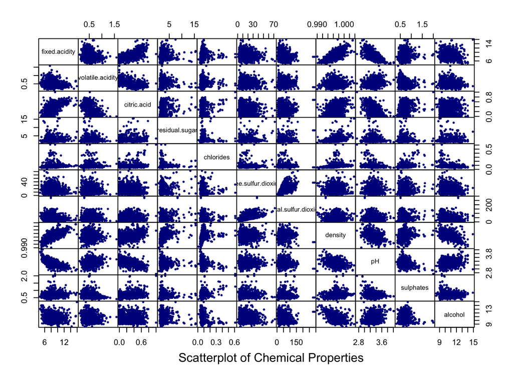

```
## numeric(0)
```

```r
# scatterplot
pairs(redwine[,2:12], gap=0, pch=19, cex=0.4, col="darkblue") + title(sub="Scatterplot of Chemical Properties", cex=0.8)
```

#### Correlation coefficients of variables vs. quality:

```r
# correlation coefficients with quality
var_redwine_quality = cor(x=redwine[,2:12], y=redwine$quality)
var_redwine_quality
```

```
##                             [,1]
## fixed.acidity         0.12405165
## volatile.acidity     -0.39055778
## citric.acid           0.22637251
## residual.sugar        0.01373164
## chlorides            -0.12890656
## free.sulfur.dioxide  -0.05065606
## total.sulfur.dioxide -0.18510029
## density              -0.17491923
## pH                   -0.05773139
## sulphates             0.25139708
## alcohol               0.47616632
```

From the var_redwine table we could also see that alcohol, volatile.acidity, sulphates and citric.acid had high impacts on quality with the correlation coefficients of 0.48, -0.39, 0.25 and 0.23 respectively.

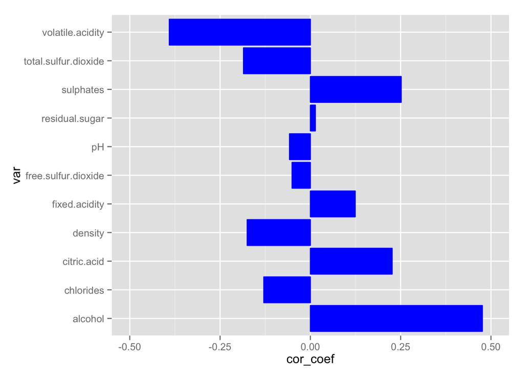

```r
# create a dataframe with correlation coefficients results--------
var = c(names(redwine)[2:12])
cor_coef = c(var_redwine_quality[1:11])
df = data.frame(var,cor_coef)

# correlation graph------------
cor_plot <- ggplot(df, aes(x = var, y = cor_coef))
cor_plot + geom_bar(stat = "identity", color = "blue", fill = "blue") + ylim(-0.5, 0.5) + coord_flip() # flip the axis for easier comparation
```

From the correlation coefficients graph, we could see that alcohol, sulphates, citric.acid, fixed.acidity had positive correlations with wine quality while volatile.acidity, total.sulfur.dioxide, density and chlorides had negative correlations with wine quality.

Alcohol, volatile.acidity, sulphates and citric.acid had highest impacts wine quality with the correlation coefficients of 0.48, -0.39, 0.25 and 0.23 respectively.

In order to see clear impacts of the chemical properties, I add new variable to group wine into 3 categories.

### 1.6 Add a new variable ‘rating’:

Creat a new variable ‘rating’ which was factored to ‘bad’ if ‘quality’ was less than or equal 4, ‘good’ if ‘quality’ was in range from 5-6, and ‘very good’ if ‘qualiy’ was greater or equal 7.

```r
# turn data in to data.table
wine_table <- data.table(redwine)

# add new rating variable
wine_table[, rating := ifelse(quality <=4, "bad",
                       ifelse(quality >=5 & quality <=6, "good",
                       ifelse(quality >=7, "very good", NA)))]
```

```
##          X fixed.acidity volatile.acidity citric.acid residual.sugar
##    1:    1           7.4            0.700        0.00            1.9
##    2:    2           7.8            0.880        0.00            2.6
##    3:    3           7.8            0.760        0.04            2.3
##    4:    4          11.2            0.280        0.56            1.9
##    5:    5           7.4            0.700        0.00            1.9
##   ---
## 1595: 1595           6.2            0.600        0.08            2.0
## 1596: 1596           5.9            0.550        0.10            2.2
## 1597: 1597           6.3            0.510        0.13            2.3
## 1598: 1598           5.9            0.645        0.12            2.0
## 1599: 1599           6.0            0.310        0.47            3.6
##       chlorides free.sulfur.dioxide total.sulfur.dioxide density   pH
##    1:     0.076                  11                   34 0.99780 3.51
##    2:     0.098                  25                   67 0.99680 3.20
```

[output cut: 21 more lines]

#### Summary of wine by rating:

```r
# group and then summarize the data
wine_table %>%
  group_by(rating) %>%
  summarize(n_obs =n())
```

```
## Source: local data table [3 x 2]
##
##      rating n_obs
##       (chr) (int)
## 1      good  1319
## 2 very good   217
## 3       bad    63
```

There were 217 very good wines, 1319 good wines and 63 bad wines.

## 3. Final plots:

### 3.1 Effects of alcohol, volatie.acidity, sulphates and citric.acid on quality:

From statisical summary, boxplots and correlation matrix, we have learned that four variables alcohol, volatile.acidity, sulphates and citric.acid had impacts on quality. To make a clearer visualization of the impacts, I choosed the point plot combined with line plot to see how average value of the variables impacts on wine quality. Since the alcohol had much larger value (10 or higher) than other variables (less than 1), I separated them into two plots.

```r
quality_vs_total_variables <- redwine %>%
  group_by(quality) %>%
  summarize(avg_alcohol = mean(alcohol),avg_citric.acid = mean(citric.acid), avg_sulphates = mean(sulphates), avg_volatile.acidity = mean(volatile.acidity)) %>%
  arrange(avg_alcohol, avg_volatile.acidity, avg_citric.acid, avg_sulphates)

quality_vs_total_variables
```

```
## Source: local data frame [6 x 5]
##
##   quality avg_alcohol avg_citric.acid avg_sulphates avg_volatile.acidity
##     (int)       (dbl)           (dbl)         (dbl)                (dbl)
## 1       5    9.899706       0.2436858     0.6209692            0.5770411
## 2       3    9.955000       0.1710000     0.5700000            0.8845000
## 3       4   10.265094       0.1741509     0.5964151            0.6939623
## 4       6   10.629519       0.2738245     0.6753292            0.4974843
## 5       7   11.465913       0.3751759     0.7412563            0.4039196
## 6       8   12.094444       0.3911111     0.7677778            0.4233333
```

Reshape the data into long format exclude alcohol.

```r
long_redwine <- melt(subset(quality_vs_total_variables, select = -c(avg_alcohol)), id.vars=c("quality")) # exclude avg_alcohol due to its much higher value
```

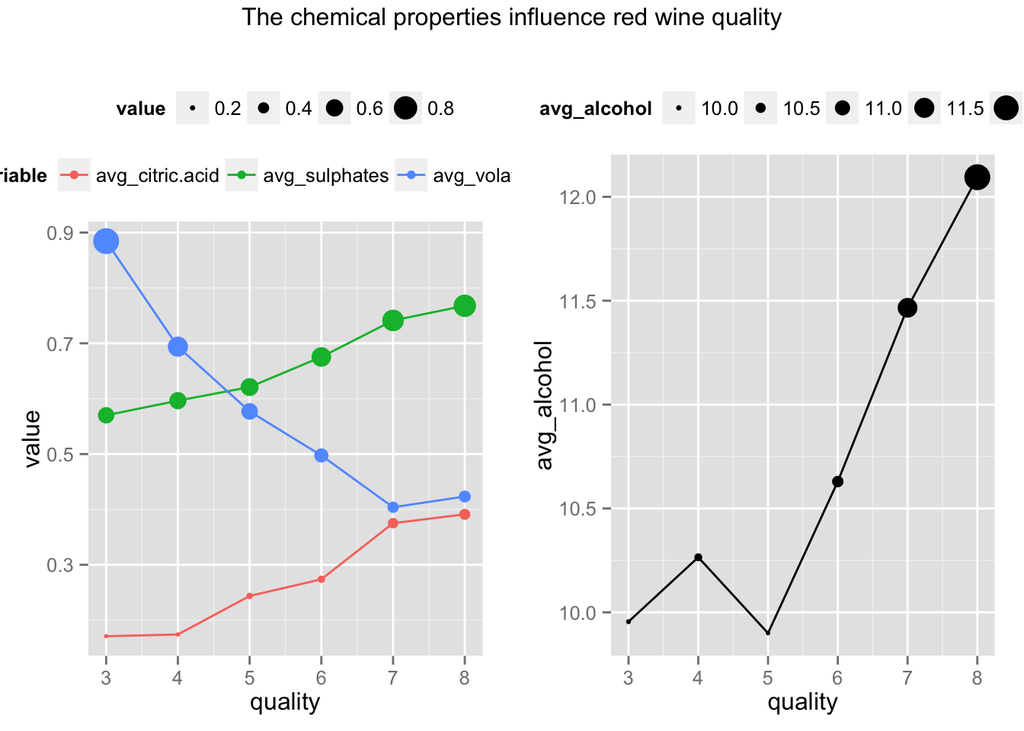

```r
plot1 = ggplot(long_redwine, aes(quality, value, colour = variable)) +
  geom_point(aes(size = value)) + geom_line() + theme(legend.position = "top")

plot2 = ggplot(quality_vs_total_variables, aes(quality, avg_alcohol)) + geom_point(aes(size = avg_alcohol)) + geom_line() + theme(legend.position = "top")

grid.arrange(plot1, plot2, ncol = 2, top="The chemical properties influence red wine quality")
```

From the above graph, we could see that with average volatile.acidity decreased, the wine quality increased respectively. While with the average sulphates, citric.acid and alcohol increased, the wine quality generally increased. We also can see that with just a small amount (0.1 g/dm^3 or less) of citric.acid and sulphated could significant increased wine quality by one level. Interestingly, with the very small changed around 0.02 g/dm^3 of citric.acid and sulphated could increased wine quality from 7-8. The chemical properties could be critical for wine with high quality.

### 3.2 Effects of alcohol, volatie.acidity, sulphates and citric.acid on rating:

From the previous analysis with boxplots and correlation matrix, we found that alcohol, volatile.acidity, sulphates and citric.acid had higher correlation coefficients with wine quality. Let explore the average of the chemical properties on wine rating.

```r
rating_vs_variables <- wine_table %>%
  group_by(rating) %>%
  # add average of selected variables
  summarize(avg_alcohol = mean(alcohol), avg_volatile.acidity = mean(volatile.acidity), avg_sulphates = mean(sulphates), avg_citric.acid = mean(citric.acid)) %>%
  arrange(avg_alcohol, avg_volatile.acidity, avg_citric.acid, avg_sulphates)

rating_vs_variables
```

```
## Source: local data table [3 x 5]
##
##      rating avg_alcohol avg_volatile.acidity avg_sulphates avg_citric.acid
##       (chr)       (dbl)                (dbl)         (dbl)           (dbl)
## 1       bad    10.21587            0.7242063     0.5922222       0.1736508
## 2      good    10.25272            0.5385595     0.6472631       0.2582638
## 3 very good    11.51805            0.4055300     0.7434562       0.3764977
```

We could see that the table that the higher concentrations of alcohol, citric.acid, sulphates are the higer wine rating is; the lower concentration of volatile.acidity is, the higher the wine rating is. Let combine the findings with the correlation coeffcients to see if they were consistant with each others.

```r
# Effects of selected variables graph
p11 = ggplot(melt(rating_vs_variables, id.vars=c("rating")), aes(rating, value, fill = variable, order = variable)) + geom_bar(position = "stack", stat = "identity") + coord_flip() + theme(legend.position = "top")
```

```

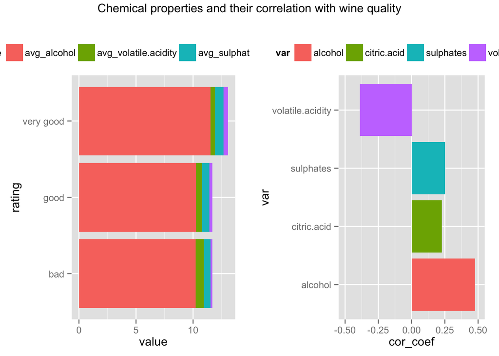

```r
# correlation coefficient graph
selected  <- c("alcohol", "volatile.acidity", "sulphates", "citric.acid")
p9 =  ggplot(data = df[df$var %in% selected,], aes(x = var, y = cor_coef, fill = var)) + geom_bar(stat = "identity") + ylim(-0.5, 0.5) + coord_flip() + theme(legend.position = "top")

# combine two plots
grid.arrange(p11, p9, ncol = 2, top = "Chemical properties and their correlation with wine quality")
```

The combined graph clearly showed that the higher alcohol, citric.acid, sulphates were the higer wine rating was ; the lower concentration of volatile.acidity was, the higher the wine rating was. The results were consisted with the correlation coefficients graph where correlation coefficients of alcohol, citric.acid and sulphates were positive while volatile.acid was negative.